# Wine Analysis by Himanshu Sharma

# Multivariate Plots Section

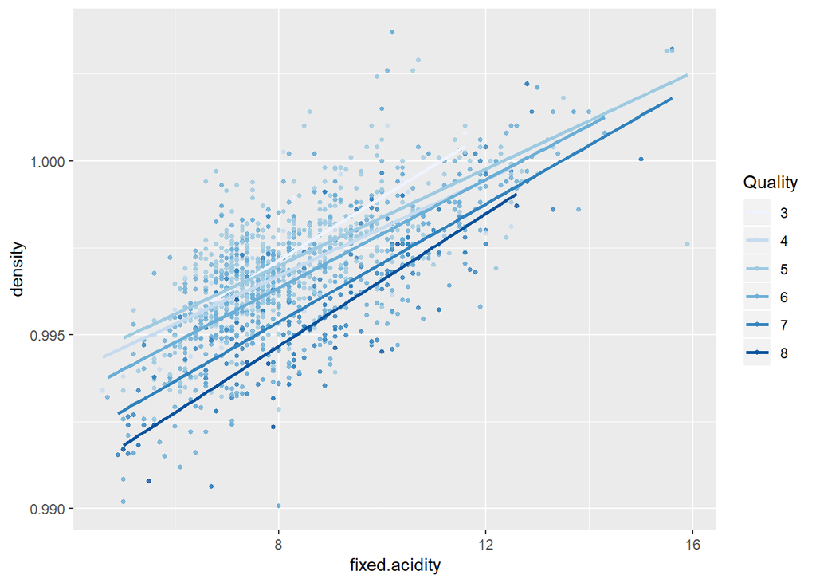

High quality wines are observed with low density and high fixed acidity while the rest of the wines are spreaded everywhere.

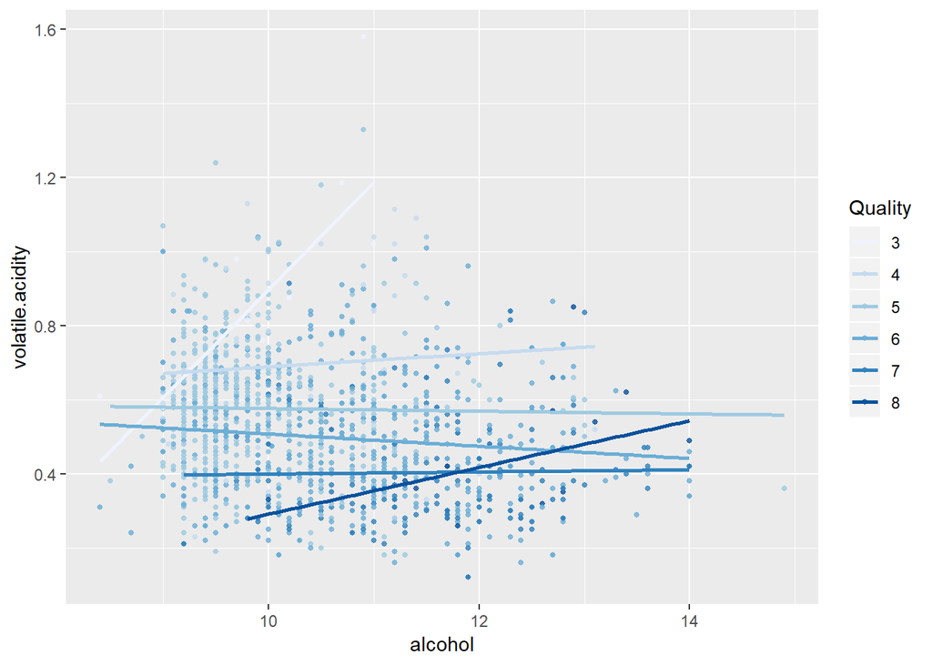

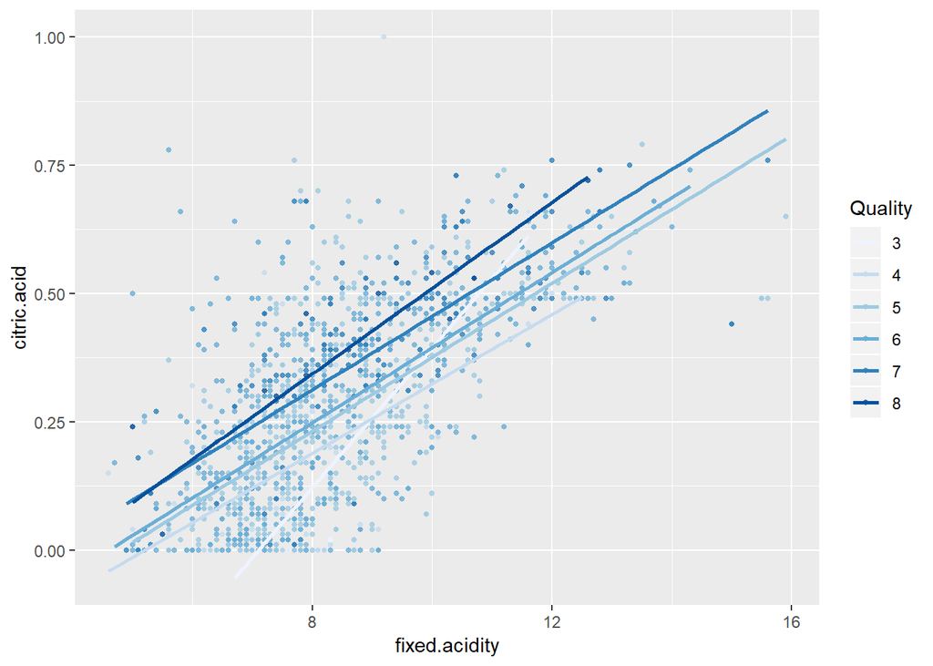

Higher quality wines are observed with higher citric.acid and fixed.acidity contents.

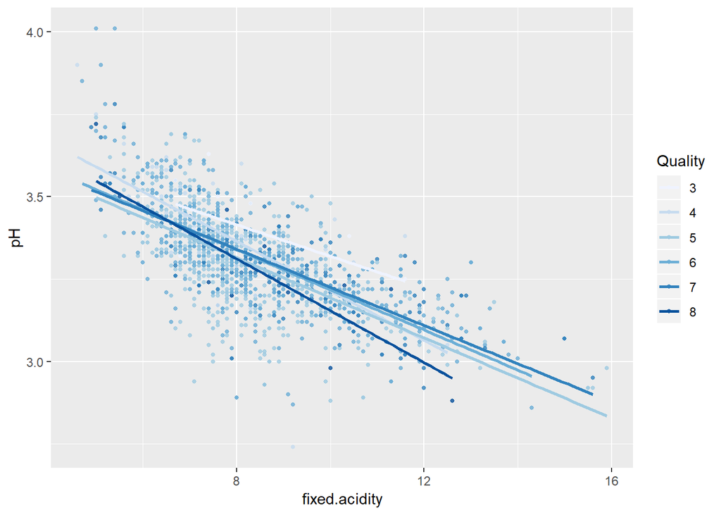

There is no such relationship in the graph.

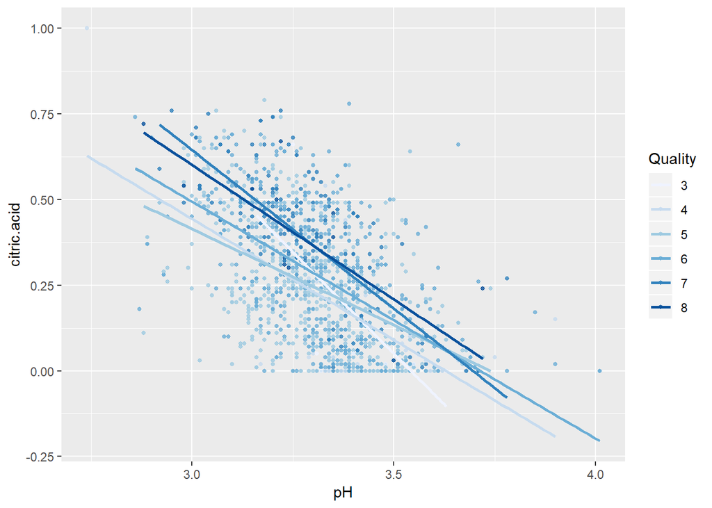

There is no such relationship in the graph.

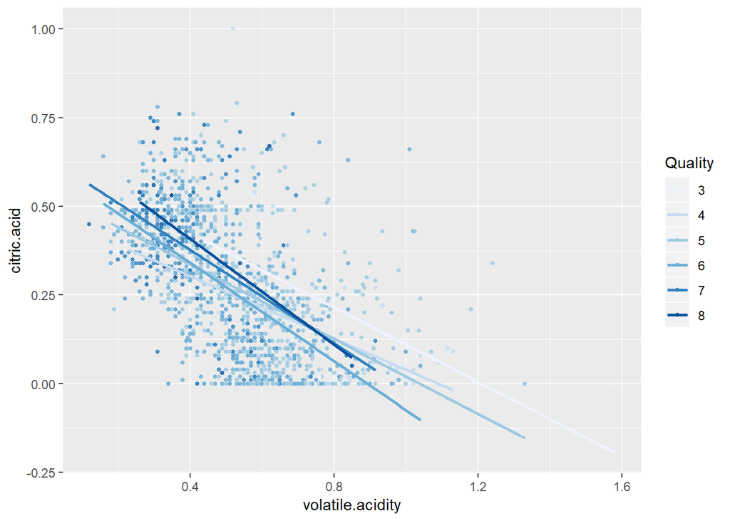

High quality wines are observed with higher citric acid content and lower volatile.acidity contents.

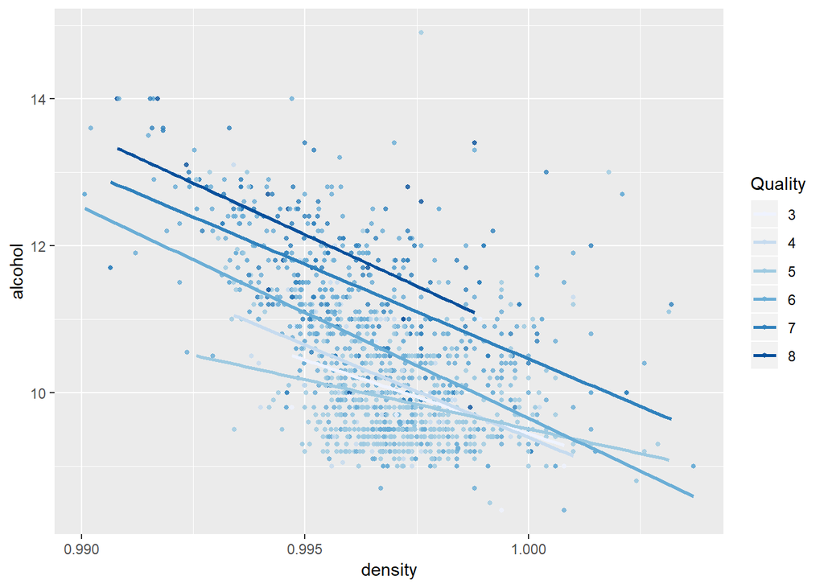

High quality wines are observed with higher alcohol content and there is no relationship simultaneously with density.

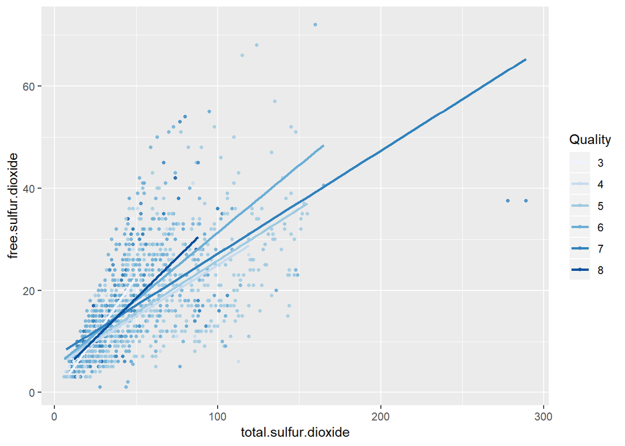

There is no relationship in the graph.

## Building a Model Using the Data Set

Notes:

```
##
## Calls:
## m1: lm(formula = I(quality) ~ I(volatile.acidity), data = winedf)
## m2: lm(formula = I(quality) ~ I(volatile.acidity) + citric.acid,
##     data = winedf)
## m3: lm(formula = I(quality) ~ I(volatile.acidity) + citric.acid +
##     sulphates, data = winedf)
## m4: lm(formula = I(quality) ~ I(volatile.acidity) + citric.acid +
##     sulphates + alcohol, data = winedf)
##
## ===============================================================================
##                             m1            m2            m3            m4
## -------------------------------------------------------------------------------
##   (Intercept)              6.566***      6.529***      6.007***      2.646***
##                           (0.058)       (0.089)       (0.116)       (0.201)
##   I(volatile.acidity)     -1.761***     -1.723***     -1.629***     -1.265***
##                           (0.104)       (0.125)       (0.124)       (0.113)
##   citric.acid                            0.063        -0.103        -0.079
##                                         (0.115)       (0.116)       (0.104)
##   sulphates                                            0.785***      0.696***
##                                                       (0.115)       (0.103)
##   alcohol                                                            0.309***
##                                                                     (0.016)
## -------------------------------------------------------------------------------
##   R-squared                0.153         0.153         0.177         0.336
##   adj. R-squared           0.152         0.152         0.175         0.334
##   sigma                    0.744         0.744         0.733         0.659
##   F                      287.444       143.812       114.278       201.777
##   p                        0.000         0.000         0.000         0.000
##   Log-likelihood       -1794.312     -1794.160     -1770.974     -1599.093
##   Deviance               883.198       883.030       857.790       691.852
##   AIC                   3594.624      3596.320      3551.948      3210.186
##   BIC                   3610.756      3617.828      3578.834      3242.448
##   N                     1599          1599          1599          1599
## ===============================================================================
```

# Multivariate Analysis

### Talk about some of the relationships you observed in this part of the investigation. Were there features that strengthened each other in terms of looking at your feature(s) of interest?

##### Higher quality wines are observed with higher citric.acid and fixed.acidity contents.

##### High quality wines are observed with higher citric acid content and lower volatile.acidity contents.

##### High quality wines are observed with higher alcohol content and there is no relationship simultaneously with density.

### Were there any interesting or surprising interactions between features?

##### No there were no suprising relationships .

### OPTIONAL: Did you create any models with your dataset? Discuss the strengths and limitations of your model.

##### It can predict the quality of the wine, but the accuracy of the model is not very good.

# Final Plots and Summary

### Plot One

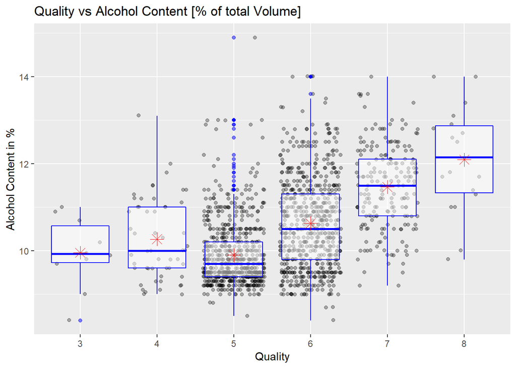

### Description One

We can see that there is a straight increase in the alcohol content with respect to increase in the quality of the wine from average to wine with the best quality. And it is obvious too the wine with a little more alcohol content have a little higher quality and rating with compare to the other. Observing mean of alcohol content grouped with respect to quality , we can see there is an increase in the alcohol content of the wines with respect to quality.

### Plot Two

[figure not shown]

### Description Two

From the above graph i observed the following :- With increase in the alcohol content[% by volume] , the density of the wines is also decreasing. It means wines with greater alcohol content are less dense as compared to the wines with less alcohol content and also possess good quality (with respect to final plot 1.)

### Plot Three

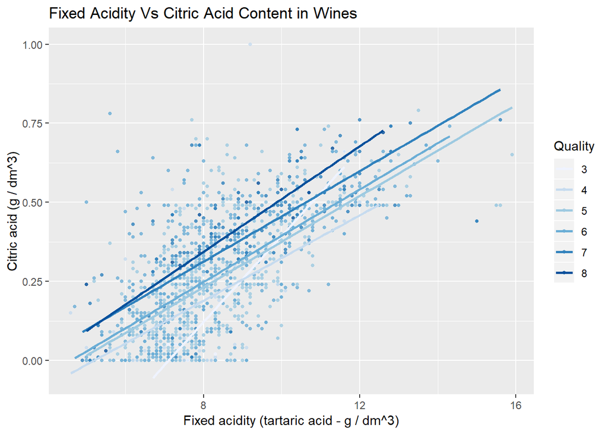

### Description Three

From the regression lines of each factor of quality , we can see that Higher quality wines are observed with higher citric.acid contents in wines and also high fixed.acidity contents.

# Reflection

> Overall experience with the dataset and analysis was good. It was good to work on a dataset which is interesting as well as informative, gained domain knowledge of wines throughout my project journey .Learned many techniques and problems that can be faced during any kind of analyis . For future perspecive, linear model can be used by wine producing companies to test and produce better quality wines and increase their sales and market shares. The major problem i faced during the analysis was the domain knowledge . So i learned that domain knowledge is must before exploring a dataset. One challenge more faced by me was i was unable to pass my variables in a function . I was stuck at that point , and unfortunately i was unable to do so . I had then changed my function to some other lines of code. Rest my experience was excellent.